# Risk Factor Analysis

## Outcome Variable

**Outcome Variable:** y_rate_wtkg

## Predictor Variables

**Intervention Variable:** predfeed36

**Adjustment Set:**

unadjusted

## Stratifying Variables

The analysis was stratified on these variable(s):

- agecat
- studyid
- country

## Data Summary

| agecat | studyid | country | predfeed36 | n_cell | n |
| --- | --- | --- | --- | --- | --- |
| 0-3 months | ki0047075b-MAL-ED | BANGLADESH | 1 | 83 | 245 |
| 0-3 months | ki0047075b-MAL-ED | BANGLADESH | 0 | 162 | 245 |
| 0-3 months | ki0047075b-MAL-ED | BRAZIL | 1 | 27 | 217 |
| 0-3 months | ki0047075b-MAL-ED | BRAZIL | 0 | 190 | 217 |
| 0-3 months | ki0047075b-MAL-ED | INDIA | 1 | 18 | 235 |
| 0-3 months | ki0047075b-MAL-ED | INDIA | 0 | 217 | 235 |
| 0-3 months | ki0047075b-MAL-ED | NEPAL | 1 | 9 | 230 |
| 0-3 months | ki0047075b-MAL-ED | NEPAL | 0 | 221 | 230 |
| 0-3 months | ki0047075b-MAL-ED | PERU | 1 | 77 | 280 |
| 0-3 months | ki0047075b-MAL-ED | PERU | 0 | 203 | 280 |
| 0-3 months | ki0047075b-MAL-ED | SOUTH AFRICA | 1 | 5 | 268 |
| 0-3 months | ki0047075b-MAL-ED | SOUTH AFRICA | 0 | 263 | 268 |
| 0-3 months | ki0047075b-MAL-ED | TANZANIA, UNITED REPUBLIC OF | 1 | 4 | 232 |
| 0-3 months | ki0047075b-MAL-ED | TANZANIA, UNITED REPUBLIC OF | 0 | 228 | 232 |
| 0-3 months | ki1000109-EE | PAKISTAN | 1 | 3 | 7 |
| 0-3 months | ki1000109-EE | PAKISTAN | 0 | 4 | 7 |
| 0-3 months | ki1113344-GMS-Nepal | NEPAL | 1 | 373 | 466 |
| 0-3 months | ki1113344-GMS-Nepal | NEPAL | 0 | 93 | 466 |
| 0-3 months | kiGH5241-JiVitA-3 | BANGLADESH | 1 | 3830 | 4900 |
| 0-3 months | kiGH5241-JiVitA-3 | BANGLADESH | 0 | 1070 | 4900 |
| 0-3 months | kiGH5241-JiVitA-4 | BANGLADESH | 1 | 499 | 582 |
| 0-3 months | kiGH5241-JiVitA-4 | BANGLADESH | 0 | 83 | 582 |
| 3-6 months | ki0047075b-MAL-ED | BANGLADESH | 1 | 78 | 232 |
| 3-6 months | ki0047075b-MAL-ED | BANGLADESH | 0 | 154 | 232 |
| 3-6 months | ki0047075b-MAL-ED | BRAZIL | 1 | 25 | 208 |
| 3-6 months | ki0047075b-MAL-ED | BRAZIL | 0 | 183 | 208 |
| 3-6 months | ki0047075b-MAL-ED | INDIA | 1 | 17 | 228 |
| 3-6 months | ki0047075b-MAL-ED | INDIA | 0 | 211 | 228 |
| 3-6 months | ki0047075b-MAL-ED | NEPAL | 1 | 8 | 232 |
| 3-6 months | ki0047075b-MAL-ED | NEPAL | 0 | 224 | 232 |

[output cut: 150 more lines]

The following strata were considered:

- agecat: 0-3 months, studyid: ki0047075b-MAL-ED, country: BANGLADESH
- agecat: 0-3 months, studyid: ki0047075b-MAL-ED, country: BRAZIL
- agecat: 0-3 months, studyid: ki0047075b-MAL-ED, country: INDIA
- agecat: 0-3 months, studyid: ki0047075b-MAL-ED, country: NEPAL
- agecat: 0-3 months, studyid: ki0047075b-MAL-ED, country: PERU
- agecat: 0-3 months, studyid: ki0047075b-MAL-ED, country: SOUTH AFRICA
- agecat: 0-3 months, studyid: ki0047075b-MAL-ED, country: TANZANIA, UNITED REPUBLIC OF
- agecat: 0-3 months, studyid: ki1000109-EE, country: PAKISTAN
- agecat: 0-3 months, studyid: ki1113344-GMS-Nepal, country: NEPAL
- agecat: 0-3 months, studyid: kiGH5241-JiVitA-3, country: BANGLADESH
- agecat: 0-3 months, studyid: kiGH5241-JiVitA-4, country: BANGLADESH
- agecat: 12-15 months, studyid: ki0047075b-MAL-ED, country: BANGLADESH
- agecat: 12-15 months, studyid: ki0047075b-MAL-ED, country: BRAZIL
- agecat: 12-15 months, studyid: ki0047075b-MAL-ED, country: INDIA
- agecat: 12-15 months, studyid: ki0047075b-MAL-ED, country: NEPAL
- agecat: 12-15 months, studyid: ki0047075b-MAL-ED, country: PERU
- agecat: 12-15 months, studyid: ki0047075b-MAL-ED, country: SOUTH AFRICA
- agecat: 12-15 months, studyid: ki0047075b-MAL-ED, country: TANZANIA, UNITED REPUBLIC OF
- agecat: 12-15 months, studyid: ki1000109-EE, country: PAKISTAN
- agecat: 12-15 months, studyid: ki1000304b-SAS-FoodSuppl, country: INDIA
- agecat: 12-15 months, studyid: ki1113344-GMS-Nepal, country: NEPAL
- agecat: 12-15 months, studyid: ki1148112-LCNI-5, country: MALAWI
- agecat: 12-15 months, studyid: kiGH5241-JiVitA-4, country: BANGLADESH
- agecat: 15-18 months, studyid: ki0047075b-MAL-ED, country: BANGLADESH
- agecat: 15-18 months, studyid: ki0047075b-MAL-ED, country: BRAZIL
- agecat: 15-18 months, studyid: ki0047075b-MAL-ED, country: INDIA
- agecat: 15-18 months, studyid: ki0047075b-MAL-ED, country: NEPAL
- agecat: 15-18 months, studyid: ki0047075b-MAL-ED, country: PERU
- agecat: 15-18 months, studyid: ki0047075b-MAL-ED, country: SOUTH AFRICA
- agecat: 15-18 months, studyid: ki0047075b-MAL-ED, country: TANZANIA, UNITED REPUBLIC OF
- agecat: 15-18 months, studyid: ki1000109-EE, country: PAKISTAN
- agecat: 15-18 months, studyid: ki1000304b-SAS-FoodSuppl, country: INDIA
- agecat: 15-18 months, studyid: ki1113344-GMS-Nepal, country: NEPAL
- agecat: 15-18 months, studyid: ki1148112-LCNI-5, country: MALAWI
- agecat: 15-18 months, studyid: kiGH5241-JiVitA-4, country: BANGLADESH
- agecat: 18-21 months, studyid: ki0047075b-MAL-ED, country: BANGLADESH
- agecat: 18-21 months, studyid: ki0047075b-MAL-ED, country: BRAZIL
- agecat: 18-21 months, studyid: ki0047075b-MAL-ED, country: INDIA
- agecat: 18-21 months, studyid: ki0047075b-MAL-ED, country: NEPAL
- agecat: 18-21 months, studyid: ki0047075b-MAL-ED, country: PERU
- agecat: 18-21 months, studyid: ki0047075b-MAL-ED, country: SOUTH AFRICA
- agecat: 18-21 months, studyid: ki0047075b-MAL-ED, country: TANZANIA, UNITED REPUBLIC OF
- agecat: 18-21 months, studyid: ki1000109-EE, country: PAKISTAN
- agecat: 18-21 months, studyid: ki1113344-GMS-Nepal, country: NEPAL
- agecat: 18-21 months, studyid: ki1148112-LCNI-5, country: MALAWI
- agecat: 21-24 months, studyid: ki0047075b-MAL-ED, country: BANGLADESH
- agecat: 21-24 months, studyid: ki0047075b-MAL-ED, country: BRAZIL
- agecat: 21-24 months, studyid: ki0047075b-MAL-ED, country: INDIA
- agecat: 21-24 months, studyid: ki0047075b-MAL-ED, country: NEPAL
- agecat: 21-24 months, studyid: ki0047075b-MAL-ED, country: PERU
- agecat: 21-24 months, studyid: ki0047075b-MAL-ED, country: SOUTH AFRICA
- agecat: 21-24 months, studyid: ki0047075b-MAL-ED, country: TANZANIA, UNITED REPUBLIC OF
- agecat: 21-24 months, studyid: ki1000109-EE, country: PAKISTAN
- agecat: 21-24 months, studyid: ki1113344-GMS-Nepal, country: NEPAL
- agecat: 21-24 months, studyid: ki1148112-LCNI-5, country: MALAWI
- agecat: 3-6 months, studyid: ki0047075b-MAL-ED, country: BANGLADESH
- agecat: 3-6 months, studyid: ki0047075b-MAL-ED, country: BRAZIL
- agecat: 3-6 months, studyid: ki0047075b-MAL-ED, country: INDIA
- agecat: 3-6 months, studyid: ki0047075b-MAL-ED, country: NEPAL
- agecat: 3-6 months, studyid: ki0047075b-MAL-ED, country: PERU
- agecat: 3-6 months, studyid: ki0047075b-MAL-ED, country: SOUTH AFRICA
- agecat: 3-6 months, studyid: ki0047075b-MAL-ED, country: TANZANIA, UNITED REPUBLIC OF
- agecat: 3-6 months, studyid: ki1000109-EE, country: PAKISTAN
- agecat: 3-6 months, studyid: ki1113344-GMS-Nepal, country: NEPAL
- agecat: 3-6 months, studyid: kiGH5241-JiVitA-3, country: BANGLADESH
- agecat: 3-6 months, studyid: kiGH5241-JiVitA-4, country: BANGLADESH
- agecat: 6-9 months, studyid: ki0047075b-MAL-ED, country: BANGLADESH
- agecat: 6-9 months, studyid: ki0047075b-MAL-ED, country: BRAZIL
- agecat: 6-9 months, studyid: ki0047075b-MAL-ED, country: INDIA
- agecat: 6-9 months, studyid: ki0047075b-MAL-ED, country: NEPAL
- agecat: 6-9 months, studyid: ki0047075b-MAL-ED, country: PERU
- agecat: 6-9 months, studyid: ki0047075b-MAL-ED, country: SOUTH AFRICA
- agecat: 6-9 months, studyid: ki0047075b-MAL-ED, country: TANZANIA, UNITED REPUBLIC OF
- agecat: 6-9 months, studyid: ki1000109-EE, country: PAKISTAN
- agecat: 6-9 months, studyid: ki1000304b-SAS-FoodSuppl, country: INDIA
- agecat: 6-9 months, studyid: ki1113344-GMS-Nepal, country: NEPAL
- agecat: 6-9 months, studyid: ki1148112-LCNI-5, country: MALAWI
- agecat: 6-9 months, studyid: kiGH5241-JiVitA-4, country: BANGLADESH
- agecat: 9-12 months, studyid: ki0047075b-MAL-ED, country: BANGLADESH
- agecat: 9-12 months, studyid: ki0047075b-MAL-ED, country: BRAZIL
- agecat: 9-12 months, studyid: ki0047075b-MAL-ED, country: INDIA
- agecat: 9-12 months, studyid: ki0047075b-MAL-ED, country: NEPAL
- agecat: 9-12 months, studyid: ki0047075b-MAL-ED, country: PERU
- agecat: 9-12 months, studyid: ki0047075b-MAL-ED, country: SOUTH AFRICA
- agecat: 9-12 months, studyid: ki0047075b-MAL-ED, country: TANZANIA, UNITED REPUBLIC OF
- agecat: 9-12 months, studyid: ki1000109-EE, country: PAKISTAN
- agecat: 9-12 months, studyid: ki1000304b-SAS-FoodSuppl, country: INDIA
- agecat: 9-12 months, studyid: ki1113344-GMS-Nepal, country: NEPAL
- agecat: 9-12 months, studyid: ki1148112-LCNI-5, country: MALAWI
- agecat: 9-12 months, studyid: kiGH5241-JiVitA-4, country: BANGLADESH

### Dropped Strata

Some strata were dropped due to rare outcomes:

- agecat: 0-3 months, studyid: ki0047075b-MAL-ED, country: TANZANIA, UNITED REPUBLIC OF
- agecat: 0-3 months, studyid: ki1000109-EE, country: PAKISTAN
- agecat: 3-6 months, studyid: ki0047075b-MAL-ED, country: SOUTH AFRICA
- agecat: 3-6 months, studyid: ki1000109-EE, country: PAKISTAN
- agecat: 6-9 months, studyid: ki0047075b-MAL-ED, country: SOUTH AFRICA
- agecat: 6-9 months, studyid: ki1000109-EE, country: PAKISTAN
- agecat: 6-9 months, studyid: ki1000304b-SAS-FoodSuppl, country: INDIA
- agecat: 9-12 months, studyid: ki0047075b-MAL-ED, country: SOUTH AFRICA
- agecat: 9-12 months, studyid: ki0047075b-MAL-ED, country: TANZANIA, UNITED REPUBLIC OF
- agecat: 9-12 months, studyid: ki1000109-EE, country: PAKISTAN
- agecat: 9-12 months, studyid: ki1000304b-SAS-FoodSuppl, country: INDIA
- agecat: 12-15 months, studyid: ki0047075b-MAL-ED, country: SOUTH AFRICA
- agecat: 12-15 months, studyid: ki0047075b-MAL-ED, country: TANZANIA, UNITED REPUBLIC OF
- agecat: 12-15 months, studyid: ki1000109-EE, country: PAKISTAN
- agecat: 12-15 months, studyid: ki1000304b-SAS-FoodSuppl, country: INDIA
- agecat: 12-15 months, studyid: ki1148112-LCNI-5, country: MALAWI
- agecat: 15-18 months, studyid: ki0047075b-MAL-ED, country: SOUTH AFRICA
- agecat: 15-18 months, studyid: ki0047075b-MAL-ED, country: TANZANIA, UNITED REPUBLIC OF
- agecat: 15-18 months, studyid: ki1000109-EE, country: PAKISTAN
- agecat: 15-18 months, studyid: ki1000304b-SAS-FoodSuppl, country: INDIA
- agecat: 15-18 months, studyid: ki1148112-LCNI-5, country: MALAWI
- agecat: 18-21 months, studyid: ki0047075b-MAL-ED, country: SOUTH AFRICA
- agecat: 18-21 months, studyid: ki0047075b-MAL-ED, country: TANZANIA, UNITED REPUBLIC OF
- agecat: 18-21 months, studyid: ki1000109-EE, country: PAKISTAN
- agecat: 21-24 months, studyid: ki0047075b-MAL-ED, country: SOUTH AFRICA
- agecat: 21-24 months, studyid: ki0047075b-MAL-ED, country: TANZANIA, UNITED REPUBLIC OF
- agecat: 21-24 months, studyid: ki1000109-EE, country: PAKISTAN

## Methods Detail

We’re interested in the causal parameters $E[Y_a]$ for all values of $a \in \mathcal{A}$. These parameters represent the mean outcome if, possibly contrary to fact, we intervened to set all units to have $A=a$. Under the randomization and positivity assumptions, these are identified by the statistical parameters $\psi_a=E_W[E_{Y|A,W}(Y|A=a,W)]$. In addition, we’re interested in the mean of $Y$, $E[Y]$ under no intervention (the observed mean). We will estimate these parameters by using SuperLearner to fit the relevant likelihood factors – $E_{Y|A,W}(Y|A=a,W)$ and $p(A=a|W)$, and then updating our likelihood fit using a joint TMLE.

For unadjusted analyses ($W=\{\}$), initial likelihoods were estimated using Lrnr_glm to estimate the simple $E(Y|A)$ and Lrnr_mean to estimate $p(A)$. For adjusted analyses, a small library containing Lrnr_glmnet, Lrnr_xgboost, and Lrnr_mean was used.

Having estimated these parameters, we will then use the delta method to estimate relative risks and attributable risks relative to a prespecified baseline level of $A$.

# Results Detail

## Results Plots

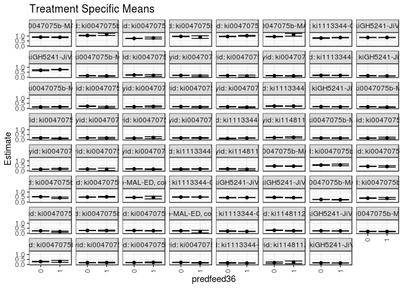

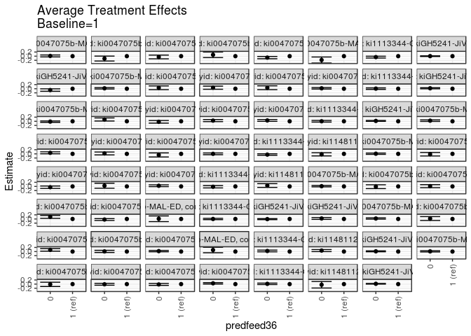

[figure not shown]

## Results Table

### Parameter: TSM

| agecat | studyid | country | intervention_level | baseline_level | estimate | ci_lower | ci_upper |
| --- | --- | --- | --- | --- | --- | --- | --- |
| 0-3 months | ki0047075b-MAL-ED | BANGLADESH | 1 | NA | 0.8724265 | 0.8361384 | 0.9087146 |
| 0-3 months | ki0047075b-MAL-ED | BANGLADESH | 0 | NA | 0.8829371 | 0.8533189 | 0.9125552 |
| 0-3 months | ki0047075b-MAL-ED | BRAZIL | 1 | NA | 1.1671966 | 1.0530674 | 1.2813257 |
| 0-3 months | ki0047075b-MAL-ED | BRAZIL | 0 | NA | 1.0510637 | 1.0158120 | 1.0863154 |
| 0-3 months | ki0047075b-MAL-ED | INDIA | 1 | NA | 0.7945237 | 0.7068002 | 0.8822472 |
| 0-3 months | ki0047075b-MAL-ED | INDIA | 0 | NA | 0.7558884 | 0.7327516 | 0.7790251 |
| 0-3 months | ki0047075b-MAL-ED | NEPAL | 1 | NA | 0.8917231 | 0.7591937 | 1.0242525 |
| 0-3 months | ki0047075b-MAL-ED | NEPAL | 0 | NA | 0.9592919 | 0.9317769 | 0.9868068 |
| 0-3 months | ki0047075b-MAL-ED | PERU | 1 | NA | 1.0217284 | 0.9750000 | 1.0684568 |
| 0-3 months | ki0047075b-MAL-ED | PERU | 0 | NA | 0.9517079 | 0.9222637 | 0.9811521 |
| 0-3 months | ki0047075b-MAL-ED | SOUTH AFRICA | 1 | NA | 1.1240287 | 0.9802729 | 1.2677845 |
| 0-3 months | ki0047075b-MAL-ED | SOUTH AFRICA | 0 | NA | 0.9375440 | 0.9105230 | 0.9645650 |
| 0-3 months | ki1113344-GMS-Nepal | NEPAL | 1 | NA | 0.8382463 | 0.8182606 | 0.8582321 |
| 0-3 months | ki1113344-GMS-Nepal | NEPAL | 0 | NA | 0.7922569 | 0.7535676 | 0.8309462 |
| 0-3 months | kiGH5241-JiVitA-3 | BANGLADESH | 1 | NA | 0.8486665 | 0.8428065 | 0.8545266 |
| 0-3 months | kiGH5241-JiVitA-3 | BANGLADESH | 0 | NA | 0.8497215 | 0.8350706 | 0.8643724 |
| 0-3 months | kiGH5241-JiVitA-4 | BANGLADESH | 1 | NA | 0.7584403 | 0.7316266 | 0.7852541 |
| 0-3 months | kiGH5241-JiVitA-4 | BANGLADESH | 0 | NA | 0.6939408 | 0.6423650 | 0.7455165 |
| 3-6 months | ki0047075b-MAL-ED | BANGLADESH | 1 | NA | 0.4666648 | 0.4409019 | 0.4924278 |
| 3-6 months | ki0047075b-MAL-ED | BANGLADESH | 0 | NA | 0.4777996 | 0.4563047 | 0.4992944 |
| 3-6 months | ki0047075b-MAL-ED | BRAZIL | 1 | NA | 0.5891702 | 0.5030439 | 0.6752964 |
| 3-6 months | ki0047075b-MAL-ED | BRAZIL | 0 | NA | 0.5766986 | 0.5432173 | 0.6101798 |
| 3-6 months | ki0047075b-MAL-ED | INDIA | 1 | NA | 0.4325358 | 0.3613177 | 0.5037540 |
| 3-6 months | ki0047075b-MAL-ED | INDIA | 0 | NA | 0.4446272 | 0.4265872 | 0.4626672 |
| 3-6 months | ki0047075b-MAL-ED | NEPAL | 1 | NA | 0.4237838 | 0.3564157 | 0.4911520 |
| 3-6 months | ki0047075b-MAL-ED | NEPAL | 0 | NA | 0.5256796 | 0.5049974 | 0.5463618 |
| 3-6 months | ki0047075b-MAL-ED | PERU | 1 | NA | 0.5181709 | 0.4786977 | 0.5576441 |
| 3-6 months | ki0047075b-MAL-ED | PERU | 0 | NA | 0.4911491 | 0.4697135 | 0.5125847 |
| 3-6 months | ki0047075b-MAL-ED | TANZANIA, UNITED REPUBLIC OF | 1 | NA | 0.4474229 | 0.3122280 | 0.5826178 |
| 3-6 months | ki0047075b-MAL-ED | TANZANIA, UNITED REPUBLIC OF | 0 | NA | 0.4580815 | 0.4333589 | 0.4828041 |

[output cut: 96 more lines]

### Parameter: E(Y)

| agecat | studyid | country | intervention_level | baseline_level | estimate | ci_lower | ci_upper |
| --- | --- | --- | --- | --- | --- | --- | --- |
| 0-3 months | ki0047075b-MAL-ED | BANGLADESH | NA | NA | 0.8793764 | 0.8562449 | 0.9025078 |
| 0-3 months | ki0047075b-MAL-ED | BRAZIL | NA | NA | 1.0655134 | 1.0311555 | 1.0998713 |
| 0-3 months | ki0047075b-MAL-ED | INDIA | NA | NA | 0.7588477 | 0.7364127 | 0.7812826 |
| 0-3 months | ki0047075b-MAL-ED | NEPAL | NA | NA | 0.9566479 | 0.9296524 | 0.9836434 |
| 0-3 months | ki0047075b-MAL-ED | PERU | NA | NA | 0.9709635 | 0.9457785 | 0.9961485 |
| 0-3 months | ki0047075b-MAL-ED | SOUTH AFRICA | NA | NA | 0.9410232 | 0.9142620 | 0.9677844 |
| 0-3 months | ki1113344-GMS-Nepal | NEPAL | NA | NA | 0.8290682 | 0.8112267 | 0.8469097 |
| 0-3 months | kiGH5241-JiVitA-3 | BANGLADESH | NA | NA | 0.8488969 | 0.8432073 | 0.8545865 |
| 0-3 months | kiGH5241-JiVitA-4 | BANGLADESH | NA | NA | 0.7492419 | 0.7250540 | 0.7734299 |
| 3-6 months | ki0047075b-MAL-ED | BANGLADESH | NA | NA | 0.4740560 | 0.4573508 | 0.4907612 |
| 3-6 months | ki0047075b-MAL-ED | BRAZIL | NA | NA | 0.5781976 | 0.5469697 | 0.6094254 |
| 3-6 months | ki0047075b-MAL-ED | INDIA | NA | NA | 0.4437256 | 0.4262017 | 0.4612496 |
| 3-6 months | ki0047075b-MAL-ED | NEPAL | NA | NA | 0.5221660 | 0.5019198 | 0.5424121 |
| 3-6 months | ki0047075b-MAL-ED | PERU | NA | NA | 0.4982335 | 0.4792789 | 0.5171881 |
| 3-6 months | ki0047075b-MAL-ED | TANZANIA, UNITED REPUBLIC OF | NA | NA | 0.4578547 | 0.4335136 | 0.4821959 |
| 3-6 months | ki1113344-GMS-Nepal | NEPAL | NA | NA | 0.4969685 | 0.4829796 | 0.5109574 |
| 3-6 months | kiGH5241-JiVitA-3 | BANGLADESH | NA | NA | 0.4411124 | 0.4337224 | 0.4485024 |
| 3-6 months | kiGH5241-JiVitA-4 | BANGLADESH | NA | NA | 0.4400358 | 0.4158687 | 0.4642029 |
| 6-9 months | ki0047075b-MAL-ED | BANGLADESH | NA | NA | 0.2428552 | 0.2283339 | 0.2573765 |
| 6-9 months | ki0047075b-MAL-ED | BRAZIL | NA | NA | 0.3831499 | 0.3570859 | 0.4092138 |
| 6-9 months | ki0047075b-MAL-ED | INDIA | NA | NA | 0.2306231 | 0.2156296 | 0.2456166 |
| 6-9 months | ki0047075b-MAL-ED | NEPAL | NA | NA | 0.2699886 | 0.2554702 | 0.2845071 |
| 6-9 months | ki0047075b-MAL-ED | PERU | NA | NA | 0.2613933 | 0.2459015 | 0.2768851 |
| 6-9 months | ki0047075b-MAL-ED | TANZANIA, UNITED REPUBLIC OF | NA | NA | 0.2385095 | 0.2143193 | 0.2626996 |
| 6-9 months | ki1113344-GMS-Nepal | NEPAL | NA | NA | 0.1871486 | 0.1748771 | 0.1994201 |
| 6-9 months | ki1148112-LCNI-5 | MALAWI | NA | NA | 0.2829175 | 0.2578313 | 0.3080037 |
| 6-9 months | kiGH5241-JiVitA-4 | BANGLADESH | NA | NA | 0.2310406 | 0.2199994 | 0.2420817 |
| 9-12 months | ki0047075b-MAL-ED | BANGLADESH | NA | NA | 0.1730346 | 0.1593686 | 0.1867006 |
| 9-12 months | ki0047075b-MAL-ED | BRAZIL | NA | NA | 0.2845923 | 0.2527896 | 0.3163950 |
| 9-12 months | ki0047075b-MAL-ED | INDIA | NA | NA | 0.1787492 | 0.1645237 | 0.1929747 |
| 9-12 months | ki0047075b-MAL-ED | NEPAL | NA | NA | 0.1857420 | 0.1712835 | 0.2002004 |
| 9-12 months | ki0047075b-MAL-ED | PERU | NA | NA | 0.1874806 | 0.1721694 | 0.2027919 |
| 9-12 months | ki1113344-GMS-Nepal | NEPAL | NA | NA | 0.1395865 | 0.1265823 | 0.1525906 |
| 9-12 months | ki1148112-LCNI-5 | MALAWI | NA | NA | 0.1849664 | 0.1167599 | 0.2531730 |
| 9-12 months | kiGH5241-JiVitA-4 | BANGLADESH | NA | NA | 0.1407721 | 0.1318530 | 0.1496912 |
| 12-15 months | ki0047075b-MAL-ED | BANGLADESH | NA | NA | 0.1353586 | 0.1195861 | 0.1511312 |
| 12-15 months | ki0047075b-MAL-ED | BRAZIL | NA | NA | 0.2101946 | 0.1853699 | 0.2350192 |
| 12-15 months | ki0047075b-MAL-ED | INDIA | NA | NA | 0.1739653 | 0.1578765 | 0.1900541 |
| 12-15 months | ki0047075b-MAL-ED | NEPAL | NA | NA | 0.1525937 | 0.1359182 | 0.1692692 |
| 12-15 months | ki0047075b-MAL-ED | PERU | NA | NA | 0.1417390 | 0.1250455 | 0.1584325 |
| 12-15 months | ki1113344-GMS-Nepal | NEPAL | NA | NA | 0.1746639 | 0.1610783 | 0.1882495 |
| 12-15 months | kiGH5241-JiVitA-4 | BANGLADESH | NA | NA | 0.1237085 | 0.1128798 | 0.1345372 |
| 15-18 months | ki0047075b-MAL-ED | BANGLADESH | NA | NA | 0.1427882 | 0.1271818 | 0.1583946 |
| 15-18 months | ki0047075b-MAL-ED | BRAZIL | NA | NA | 0.2034195 | 0.1767881 | 0.2300509 |
| 15-18 months | ki0047075b-MAL-ED | INDIA | NA | NA | 0.1642299 | 0.1493519 | 0.1791079 |
| 15-18 months | ki0047075b-MAL-ED | NEPAL | NA | NA | 0.1731820 | 0.1573733 | 0.1889907 |
| 15-18 months | ki0047075b-MAL-ED | PERU | NA | NA | 0.1461889 | 0.1273267 | 0.1650511 |
| 15-18 months | ki1113344-GMS-Nepal | NEPAL | NA | NA | 0.2291397 | 0.2134657 | 0.2448138 |
| 15-18 months | kiGH5241-JiVitA-4 | BANGLADESH | NA | NA | 0.1576719 | 0.1473147 | 0.1680291 |
| 18-21 months | ki0047075b-MAL-ED | BANGLADESH | NA | NA | 0.1427146 | 0.1257942 | 0.1596351 |
| 18-21 months | ki0047075b-MAL-ED | BRAZIL | NA | NA | 0.1606491 | 0.1365241 | 0.1847741 |
| 18-21 months | ki0047075b-MAL-ED | INDIA | NA | NA | 0.1701596 | 0.1556514 | 0.1846677 |
| 18-21 months | ki0047075b-MAL-ED | NEPAL | NA | NA | 0.1474939 | 0.1297619 | 0.1652260 |
| 18-21 months | ki0047075b-MAL-ED | PERU | NA | NA | 0.1615652 | 0.1425950 | 0.1805355 |
| 18-21 months | ki1113344-GMS-Nepal | NEPAL | NA | NA | 0.1428759 | 0.1266216 | 0.1591302 |
| 18-21 months | ki1148112-LCNI-5 | MALAWI | NA | NA | 0.2016785 | 0.1726437 | 0.2307133 |
| 21-24 months | ki0047075b-MAL-ED | BANGLADESH | NA | NA | 0.1521155 | 0.1369898 | 0.1672413 |
| 21-24 months | ki0047075b-MAL-ED | BRAZIL | NA | NA | 0.1434900 | 0.1201394 | 0.1668407 |
| 21-24 months | ki0047075b-MAL-ED | INDIA | NA | NA | 0.1565193 | 0.1433011 | 0.1697376 |
| 21-24 months | ki0047075b-MAL-ED | NEPAL | NA | NA | 0.1696243 | 0.1496620 | 0.1895867 |
| 21-24 months | ki0047075b-MAL-ED | PERU | NA | NA | 0.1814671 | 0.1617319 | 0.2012023 |
| 21-24 months | ki1113344-GMS-Nepal | NEPAL | NA | NA | 0.1784694 | 0.1533807 | 0.2035582 |
| 21-24 months | ki1148112-LCNI-5 | MALAWI | NA | NA | 0.1779746 | 0.1356818 | 0.2202674 |

### Parameter: ATE

| agecat | studyid | country | intervention_level | baseline_level | estimate | ci_lower | ci_upper |
| --- | --- | --- | --- | --- | --- | --- | --- |
| 0-3 months | ki0047075b-MAL-ED | BANGLADESH | 1 | 1 | 0.0000000 | 0.0000000 | 0.0000000 |
| 0-3 months | ki0047075b-MAL-ED | BANGLADESH | 0 | 1 | 0.0105105 | -0.0363303 | 0.0573513 |
| 0-3 months | ki0047075b-MAL-ED | BRAZIL | 1 | 1 | 0.0000000 | 0.0000000 | 0.0000000 |
| 0-3 months | ki0047075b-MAL-ED | BRAZIL | 0 | 1 | -0.1161329 | -0.2355822 | 0.0033165 |
| 0-3 months | ki0047075b-MAL-ED | INDIA | 1 | 1 | 0.0000000 | 0.0000000 | 0.0000000 |
| 0-3 months | ki0047075b-MAL-ED | INDIA | 0 | 1 | -0.0386353 | -0.1293587 | 0.0520880 |
| 0-3 months | ki0047075b-MAL-ED | NEPAL | 1 | 1 | 0.0000000 | 0.0000000 | 0.0000000 |
| 0-3 months | ki0047075b-MAL-ED | NEPAL | 0 | 1 | 0.0675688 | -0.0677867 | 0.2029243 |
| 0-3 months | ki0047075b-MAL-ED | PERU | 1 | 1 | 0.0000000 | 0.0000000 | 0.0000000 |
| 0-3 months | ki0047075b-MAL-ED | PERU | 0 | 1 | -0.0700205 | -0.1252519 | -0.0147891 |
| 0-3 months | ki0047075b-MAL-ED | SOUTH AFRICA | 1 | 1 | 0.0000000 | 0.0000000 | 0.0000000 |
| 0-3 months | ki0047075b-MAL-ED | SOUTH AFRICA | 0 | 1 | -0.1864847 | -0.3327579 | -0.0402114 |
| 0-3 months | ki1113344-GMS-Nepal | NEPAL | 1 | 1 | 0.0000000 | 0.0000000 | 0.0000000 |
| 0-3 months | ki1113344-GMS-Nepal | NEPAL | 0 | 1 | -0.0459894 | -0.0895359 | -0.0024430 |
| 0-3 months | kiGH5241-JiVitA-3 | BANGLADESH | 1 | 1 | 0.0000000 | 0.0000000 | 0.0000000 |
| 0-3 months | kiGH5241-JiVitA-3 | BANGLADESH | 0 | 1 | 0.0010550 | -0.0145024 | 0.0166123 |
| 0-3 months | kiGH5241-JiVitA-4 | BANGLADESH | 1 | 1 | 0.0000000 | 0.0000000 | 0.0000000 |
| 0-3 months | kiGH5241-JiVitA-4 | BANGLADESH | 0 | 1 | -0.0644996 | -0.1239812 | -0.0050179 |
| 3-6 months | ki0047075b-MAL-ED | BANGLADESH | 1 | 1 | 0.0000000 | 0.0000000 | 0.0000000 |
| 3-6 months | ki0047075b-MAL-ED | BANGLADESH | 0 | 1 | 0.0111347 | -0.0224176 | 0.0446870 |
| 3-6 months | ki0047075b-MAL-ED | BRAZIL | 1 | 1 | 0.0000000 | 0.0000000 | 0.0000000 |
| 3-6 months | ki0047075b-MAL-ED | BRAZIL | 0 | 1 | -0.0124716 | -0.1048768 | 0.0799336 |
| 3-6 months | ki0047075b-MAL-ED | INDIA | 1 | 1 | 0.0000000 | 0.0000000 | 0.0000000 |
| 3-6 months | ki0047075b-MAL-ED | INDIA | 0 | 1 | 0.0120914 | -0.0613761 | 0.0855588 |
| 3-6 months | ki0047075b-MAL-ED | NEPAL | 1 | 1 | 0.0000000 | 0.0000000 | 0.0000000 |
| 3-6 months | ki0047075b-MAL-ED | NEPAL | 0 | 1 | 0.1018958 | 0.0314244 | 0.1723672 |
| 3-6 months | ki0047075b-MAL-ED | PERU | 1 | 1 | 0.0000000 | 0.0000000 | 0.0000000 |
| 3-6 months | ki0047075b-MAL-ED | PERU | 0 | 1 | -0.0270218 | -0.0719398 | 0.0178961 |
| 3-6 months | ki0047075b-MAL-ED | TANZANIA, UNITED REPUBLIC OF | 1 | 1 | 0.0000000 | 0.0000000 | 0.0000000 |
| 3-6 months | ki0047075b-MAL-ED | TANZANIA, UNITED REPUBLIC OF | 0 | 1 | 0.0106586 | -0.1267782 | 0.1480954 |

[output cut: 96 more lines]

### Parameter: PAR

| agecat | studyid | country | intervention_level | baseline_level | estimate | ci_lower | ci_upper |
| --- | --- | --- | --- | --- | --- | --- | --- |
| 0-3 months | ki0047075b-MAL-ED | BANGLADESH | 1 | NA | 0.0069498 | -0.0240287 | 0.0379284 |
| 0-3 months | ki0047075b-MAL-ED | BRAZIL | 1 | NA | -0.1016831 | -0.2063950 | 0.0030287 |
| 0-3 months | ki0047075b-MAL-ED | INDIA | 1 | NA | -0.0356760 | -0.1194607 | 0.0481086 |
| 0-3 months | ki0047075b-MAL-ED | NEPAL | 1 | NA | 0.0649248 | -0.0651452 | 0.1949949 |
| 0-3 months | ki0047075b-MAL-ED | PERU | 1 | NA | -0.0507649 | -0.0909753 | -0.0105544 |
| 0-3 months | ki0047075b-MAL-ED | SOUTH AFRICA | 1 | NA | -0.1830055 | -0.3256540 | -0.0403569 |
| 0-3 months | ki1113344-GMS-Nepal | NEPAL | 1 | NA | -0.0091782 | -0.0180279 | -0.0003284 |
| 0-3 months | kiGH5241-JiVitA-3 | BANGLADESH | 1 | NA | 0.0002304 | -0.0031623 | 0.0036230 |
| 0-3 months | kiGH5241-JiVitA-4 | BANGLADESH | 1 | NA | -0.0091984 | -0.0179942 | -0.0004026 |
| 3-6 months | ki0047075b-MAL-ED | BANGLADESH | 1 | NA | 0.0073912 | -0.0148909 | 0.0296733 |
| 3-6 months | ki0047075b-MAL-ED | BRAZIL | 1 | NA | -0.0109726 | -0.0922733 | 0.0703281 |
| 3-6 months | ki0047075b-MAL-ED | INDIA | 1 | NA | 0.0111898 | -0.0568010 | 0.0791807 |
| 3-6 months | ki0047075b-MAL-ED | NEPAL | 1 | NA | 0.0983821 | 0.0302985 | 0.1664657 |
| 3-6 months | ki0047075b-MAL-ED | PERU | 1 | NA | -0.0199374 | -0.0531099 | 0.0132350 |
| 3-6 months | ki0047075b-MAL-ED | TANZANIA, UNITED REPUBLIC OF | 1 | NA | 0.0104319 | -0.1235692 | 0.1444329 |
| 3-6 months | ki1113344-GMS-Nepal | NEPAL | 1 | NA | 0.0000639 | -0.0063878 | 0.0065155 |
| 3-6 months | kiGH5241-JiVitA-3 | BANGLADESH | 1 | NA | -0.0015892 | -0.0071494 | 0.0039710 |
| 3-6 months | kiGH5241-JiVitA-4 | BANGLADESH | 1 | NA | 0.0036858 | -0.0027850 | 0.0101565 |
| 6-9 months | ki0047075b-MAL-ED | BANGLADESH | 1 | NA | 0.0153833 | -0.0061281 | 0.0368947 |
| 6-9 months | ki0047075b-MAL-ED | BRAZIL | 1 | NA | 0.0189819 | -0.0628523 | 0.1008160 |
| 6-9 months | ki0047075b-MAL-ED | INDIA | 1 | NA | 0.0750093 | 0.0174688 | 0.1325499 |
| 6-9 months | ki0047075b-MAL-ED | NEPAL | 1 | NA | 0.0071925 | -0.0429613 | 0.0573464 |
| 6-9 months | ki0047075b-MAL-ED | PERU | 1 | NA | 0.0148837 | -0.0086646 | 0.0384320 |
| 6-9 months | ki0047075b-MAL-ED | TANZANIA, UNITED REPUBLIC OF | 1 | NA | 0.0733124 | -0.0565170 | 0.2031417 |
| 6-9 months | ki1113344-GMS-Nepal | NEPAL | 1 | NA | 0.0052710 | -0.0027172 | 0.0132592 |
| 6-9 months | ki1148112-LCNI-5 | MALAWI | 1 | NA | 0.0396105 | -0.0022362 | 0.0814572 |
| 6-9 months | kiGH5241-JiVitA-4 | BANGLADESH | 1 | NA | 0.0021732 | -0.0022603 | 0.0066068 |
| 9-12 months | ki0047075b-MAL-ED | BANGLADESH | 1 | NA | 0.0054694 | -0.0143786 | 0.0253175 |
| 9-12 months | ki0047075b-MAL-ED | BRAZIL | 1 | NA | -0.0101718 | -0.1017098 | 0.0813663 |
| 9-12 months | ki0047075b-MAL-ED | INDIA | 1 | NA | -0.0073040 | -0.0493105 | 0.0347024 |
| 9-12 months | ki0047075b-MAL-ED | NEPAL | 1 | NA | -0.0149358 | -0.0599333 | 0.0300617 |
| 9-12 months | ki0047075b-MAL-ED | PERU | 1 | NA | 0.0281203 | 0.0034885 | 0.0527521 |
| 9-12 months | ki1113344-GMS-Nepal | NEPAL | 1 | NA | 0.0024045 | -0.0039010 | 0.0087100 |
| 9-12 months | ki1148112-LCNI-5 | MALAWI | 1 | NA | -0.0211070 | -0.1278851 | 0.0856710 |
| 9-12 months | kiGH5241-JiVitA-4 | BANGLADESH | 1 | NA | 0.0032978 | -0.0002511 | 0.0068467 |
| 12-15 months | ki0047075b-MAL-ED | BANGLADESH | 1 | NA | 0.0138444 | -0.0089472 | 0.0366360 |
| 12-15 months | ki0047075b-MAL-ED | BRAZIL | 1 | NA | 0.0404451 | -0.0377716 | 0.1186617 |
| 12-15 months | ki0047075b-MAL-ED | INDIA | 1 | NA | 0.0459157 | -0.0241445 | 0.1159759 |
| 12-15 months | ki0047075b-MAL-ED | NEPAL | 1 | NA | 0.0467522 | -0.0427309 | 0.1362354 |
| 12-15 months | ki0047075b-MAL-ED | PERU | 1 | NA | 0.0151803 | -0.0109245 | 0.0412852 |
| 12-15 months | ki1113344-GMS-Nepal | NEPAL | 1 | NA | 0.0009765 | -0.0057909 | 0.0077439 |
| 12-15 months | kiGH5241-JiVitA-4 | BANGLADESH | 1 | NA | 0.0043770 | -0.0013525 | 0.0101064 |
| 15-18 months | ki0047075b-MAL-ED | BANGLADESH | 1 | NA | -0.0106001 | -0.0332458 | 0.0120457 |
| 15-18 months | ki0047075b-MAL-ED | BRAZIL | 1 | NA | 0.0770532 | 0.0120384 | 0.1420680 |
| 15-18 months | ki0047075b-MAL-ED | INDIA | 1 | NA | -0.0233467 | -0.0814887 | 0.0347952 |
| 15-18 months | ki0047075b-MAL-ED | NEPAL | 1 | NA | 0.0323446 | -0.0163637 | 0.0810528 |
| 15-18 months | ki0047075b-MAL-ED | PERU | 1 | NA | 0.0297995 | -0.0026742 | 0.0622732 |
| 15-18 months | ki1113344-GMS-Nepal | NEPAL | 1 | NA | 0.0003077 | -0.0075760 | 0.0081913 |
| 15-18 months | kiGH5241-JiVitA-4 | BANGLADESH | 1 | NA | 0.0037429 | -0.0005987 | 0.0080846 |
| 18-21 months | ki0047075b-MAL-ED | BANGLADESH | 1 | NA | 0.0202952 | -0.0049052 | 0.0454955 |
| 18-21 months | ki0047075b-MAL-ED | BRAZIL | 1 | NA | 0.0443187 | 0.0024034 | 0.0862339 |
| 18-21 months | ki0047075b-MAL-ED | INDIA | 1 | NA | 0.0178770 | -0.0467324 | 0.0824863 |
| 18-21 months | ki0047075b-MAL-ED | NEPAL | 1 | NA | -0.0500002 | -0.1458218 | 0.0458213 |
| 18-21 months | ki0047075b-MAL-ED | PERU | 1 | NA | 0.0009514 | -0.0303071 | 0.0322099 |
| 18-21 months | ki1113344-GMS-Nepal | NEPAL | 1 | NA | -0.0068567 | -0.0142075 | 0.0004941 |
| 18-21 months | ki1148112-LCNI-5 | MALAWI | 1 | NA | -0.0182813 | -0.0826623 | 0.0460998 |
| 21-24 months | ki0047075b-MAL-ED | BANGLADESH | 1 | NA | 0.0052156 | -0.0158988 | 0.0263301 |
| 21-24 months | ki0047075b-MAL-ED | BRAZIL | 1 | NA | -0.0151960 | -0.0906742 | 0.0602821 |
| 21-24 months | ki0047075b-MAL-ED | INDIA | 1 | NA | -0.0347443 | -0.0893383 | 0.0198498 |
| 21-24 months | ki0047075b-MAL-ED | NEPAL | 1 | NA | 0.0327130 | -0.0847755 | 0.1502015 |
| 21-24 months | ki0047075b-MAL-ED | PERU | 1 | NA | 0.0238414 | -0.0078848 | 0.0555675 |
| 21-24 months | ki1113344-GMS-Nepal | NEPAL | 1 | NA | -0.0028863 | -0.0129132 | 0.0071406 |
| 21-24 months | ki1148112-LCNI-5 | MALAWI | 1 | NA | 0.0355803 | -0.0389438 | 0.1101043 |